# Data Science and Data Analytics

The Data Science Workflow II – Visualize

Julian Amon, PhD

Charlotte Fresenius Privatuniversität

April 10, 2026

# First steps in data visualization

## The Data Science workflow – Visualize

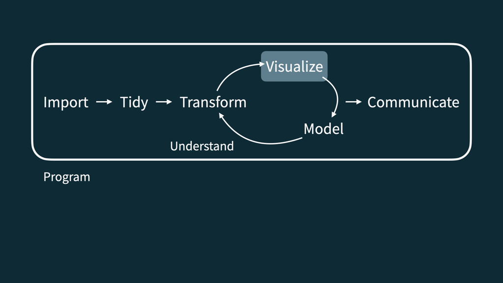

## Why even look at data?

- Given the multitude of ways we can describe data numerically (using descriptive statistics), why do we even bother to present data visually?
- The answer is that descriptive statistics can never tell us the full story about our data. Consider the following artificial data set from Anscombe (1973):

It is a collection of four data sets, each with 11 observations for variables `x` and `y`. Here is the first 2 rows of each:

```
   data_id  x     y
1        1 10  8.04
2        1  8  6.95
12       2 10  9.14
13       2  8  8.14
24       3  8  6.77
25       3 13 12.74
36       4  8  7.71
37       4  8  8.84
```

All these four data sets have: same mean and SD in `x` and `y`, and same correlation between them:

```
  data_id mean_x  sd_x mean_y  sd_y   cor
1       1      9 3.317  7.501 2.032 0.816
2       2      9 3.317  7.501 2.032 0.816
3       3      9 3.317  7.500 2.030 0.816
4       4      9 3.317  7.501 2.031 0.817
```

So, seems like these data sets should look pretty similar, right?

## Why even look at data?

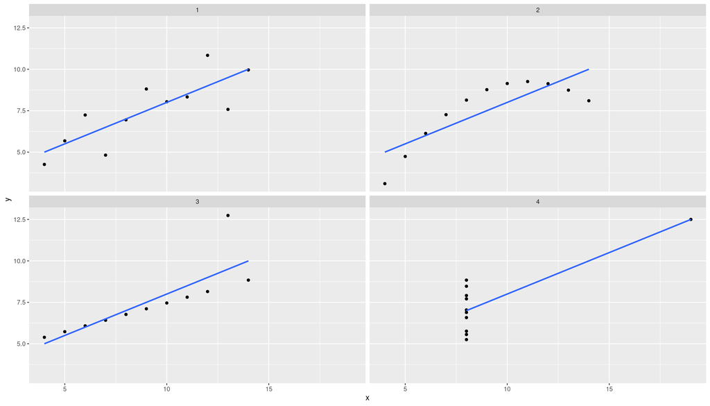

## Why even look at data?

- While this is an extreme, manufactured example, it does prove a point: visualizing data offers insight that the study of pure statistics does not.
- But that does not mean looking at data is all one needs to do:
  - Real data sets are often complicated and messy, displaying them graphically presents problems of its own.
  - The core problem of visualization is how to **map** relations between observations to visual representations in the plot, like shape, lines, colour, size, etc.
  - How to do this optimally for each given data set is subject to considerable debate. There is no simple recipe to follow.
- Fortunately, however, there is software that provides a lot of support in our data visualization endeavours.

## Data visualization in R

“The simple graph has brought more information to the data analyst’s mind than any other device.”

John Tukey (Statistician, 1915 - 2000)

- There are many tools for visualizing data. Of course, we use R 😉
- Even with R, there are many approaches / systems / packages for creating data visualizations. By far the most common one is the package `ggplot2`.
- The **gg** in `ggplot2` stands for the **grammar of graphics**, which is a coherent system for describing and building graphs developed by statistician Leland Wilkinson in his aptly named 2005 book.
- As we will see in great detail, this system constructs plots in layers that are built on top of one another in an additive fashion.

## The grammar of graphics

The grammar is a set of rules for producing graphics from data, taking pieces of data and mapping them to **geometric objects** (like points and lines) that have **aesthetic attributes** (like position, colour and size), together with further rules for transforming the data if needed, adjusting scales, adapting coordinate system and themes.

[figure not shown]

**Note**: a grammar limits the structure of what you can say, but it does not automatically make what you say meaningful, i.e. your code just being “grammatically” correct does not make the resulting plot sensible.

## An introductory example – Palmer penguins

Let’s see an example of how this works with `ggplot2` in practice.

- The data set we will use for our first `ggplot` is the [**palmerpenguins**](https://education.rstudio.com/blog/2020/07/palmerpenguins-cran/) data set that can be obtained from CRAN in a package that bears exactly that name.
- It contains size measurements, clutch observations, and blood isotope ratios for **three penguin species** observed on three islands in the Palmer Archipelago, Antarctica over a study period of three years.

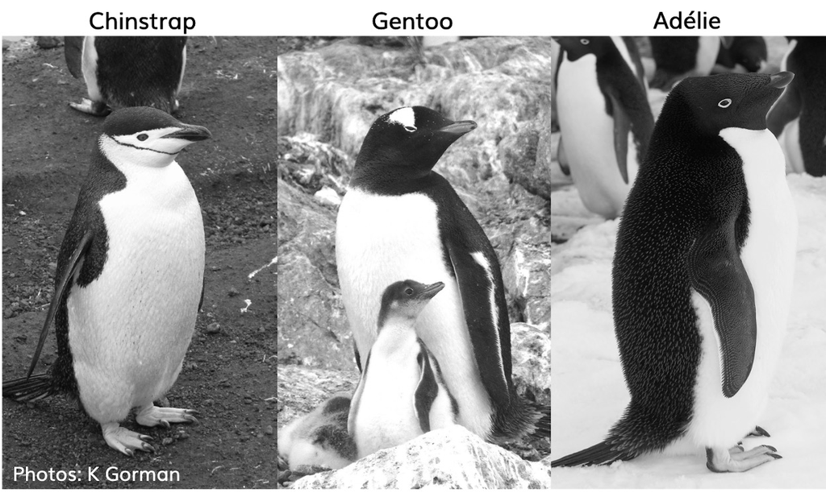

## An introductory example – Palmer penguins

Make sure the required packages `palmerpenguins` and `ggplot2` are installed. Then we can load them and start by inspecting the data set:

```r
library(palmerpenguins)
library(ggplot2)

penguins <- as.data.frame(penguins)
head(penguins)
```

```
  species    island bill_length_mm bill_depth_mm flipper_length_mm body_mass_g
1  Adelie Torgersen           39.1          18.7               181        3750
2  Adelie Torgersen           39.5          17.4               186        3800
3  Adelie Torgersen           40.3          18.0               195        3250
4  Adelie Torgersen             NA            NA                NA          NA
5  Adelie Torgersen           36.7          19.3               193        3450
6  Adelie Torgersen           39.3          20.6               190        3650
     sex year
1   male 2007
2 female 2007
3 female 2007
4   <NA> 2007
5 female 2007
6   male 2007
```

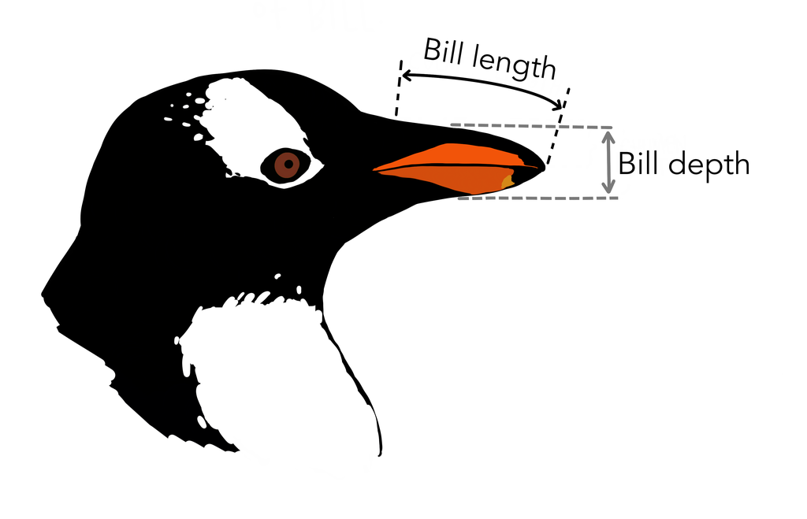

Artwork by [@allison_horst](https://allisonhorst.com/)

## An introductory example – Palmer penguins

As zoologists, we might be interested in the following questions about the different types of Palmer penguins:

- Do penguins with longer flippers weigh more or less than penguins with shorter flippers?
- What does the relationship between **flipper length** and **body mass** look like? Is it positive? Negative? Linear? Non-linear?
- Does the relationship vary by the species of the penguin? How about by the island where the penguin lives?

Let’s answer all of these questions using a single visualization.

## An introductory example – Ultimate goal

Ultimately, we want to create the following plot:

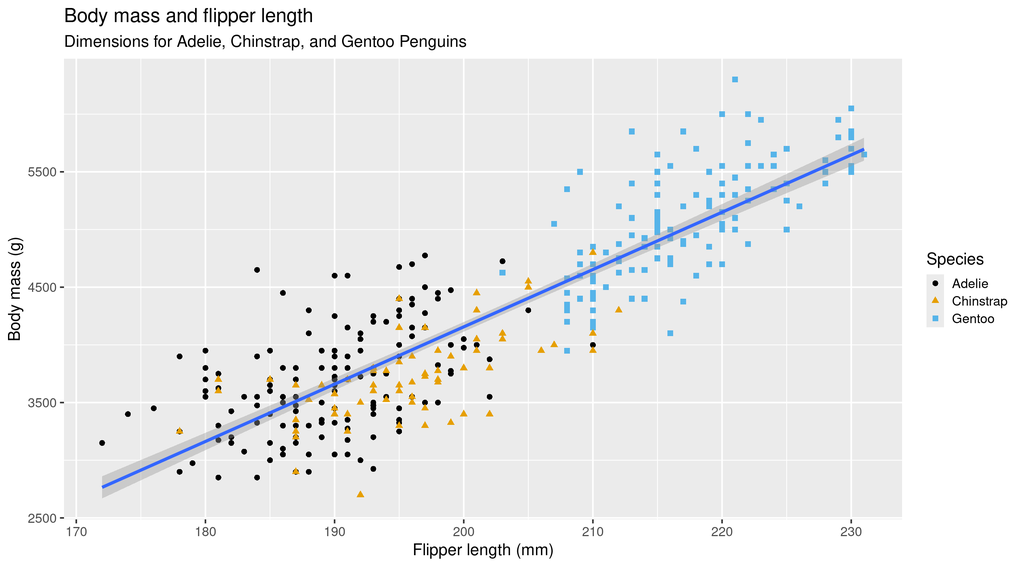

## First step – Telling ggplot about our data set

Let’s recreate this plot step-by-step.

With `ggplot2`, we begin a plot with the function `ggplot`. Its first argument is the dataset to use in the graph.

```r
ggplot(data = penguins)
```

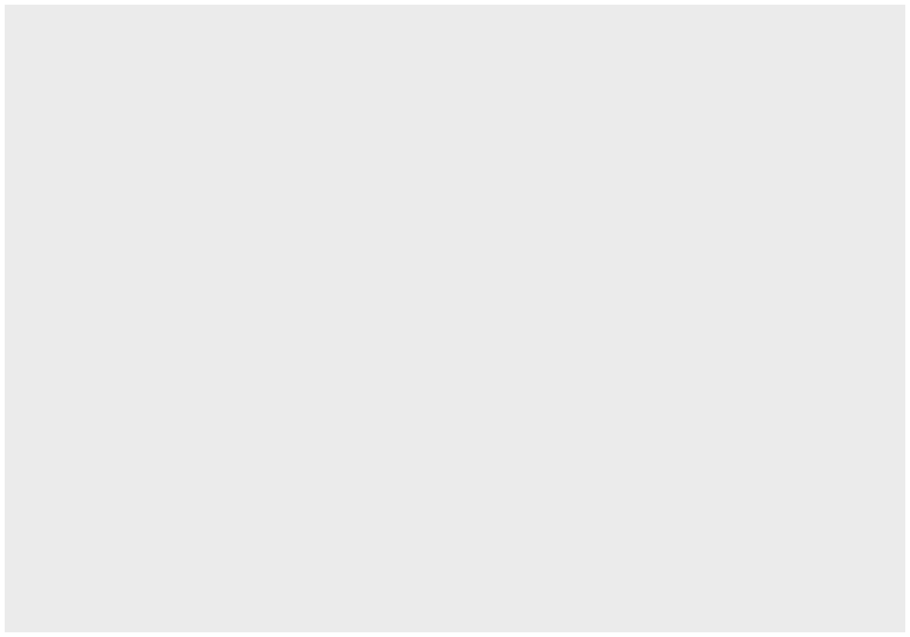

For now, we have not told `ggplot` how to visualize the data, so we only have an empty canvas. Now, we will “paint” onto this canvas in layers.

## Second step – Specifying aesthetic mappings

The second argument of `ggplot` is called `mapping`. It defines how variables in our data set are **mapped** to visual properties (**aesthetics**) of our plot. This argument is always defined in the `aes` function, and the `x` and `y` arguments of `aes` specify which variables to map to the x- and y-axes. We want flipper length on the `x` and body mass on the `y` axis.

```r
ggplot(data = penguins,
       mapping = aes(x = flipper_length_mm,
                     y = body_mass_g))
```

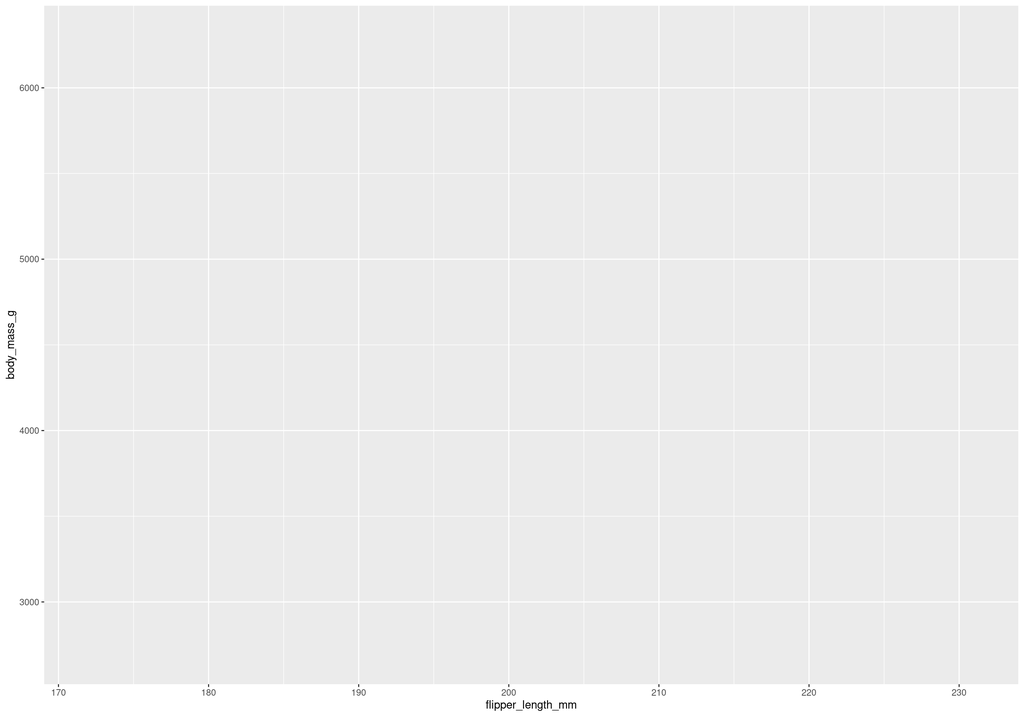

Now, our empty canvas has more structure: x- and y-axis have a range, ticks and labels. But the penguins themselves are not yet on the plot.

## Third step – Additively layer on geoms

This is because we have not yet articulated, in our code, **how** to represent the observations from our data frame on our plot. To do so, we need a **geom**, a geometrical object used for data representation. In the example, we want our data represented by points, so we use `geom_point`:

```r
ggplot(data = penguins,
       mapping = aes(x = flipper_length_mm,
                     y = body_mass_g)) +
  geom_point()
```

```
Warning: Removed 2 rows containing missing values or values outside the scale range
(`geom_point()`).
```

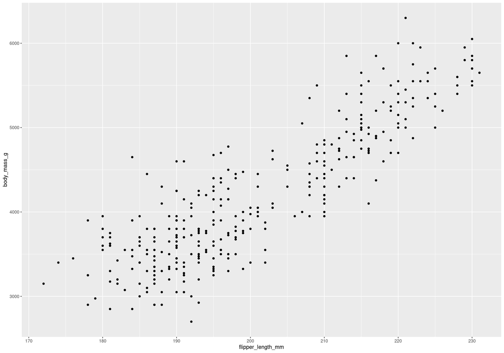

Now, we start to have an actual **scatter plot**. Note that R warns us about missing data points. We will suppress this warning in the plots to come.

## A note about geoms

In **ggplot2**, geometric objects are made available with functions that start with `geom_`. People often describe plots by the type of geom that the plot uses, for example:

- Scatter plots use point geoms (`geom_point`) as we just saw.
- Bar charts use bar geoms (`geom_bar`)
- Line charts use line geoms (`geom_line`)
- Boxplots use boxplot geoms (`geom_boxplot`)
- …

We layer a **geom** onto a ggplot literally in an **additive way**, i.e. by combining the two with a `+` sign. We will learn how to deal with many different geoms in this way.

## Fourth step – Adding aesthetics and layers

Does the relationship between flipper length and body mass differ by species? To answer this, let’s represent species with different coloured points. To achieve this, we modify the **aesthetic** to additionally map species to colour:

```r
ggplot(data = penguins,
       mapping = aes(x = flipper_length_mm,
                     y = body_mass_g,
                     color = species)) +
  geom_point()
```

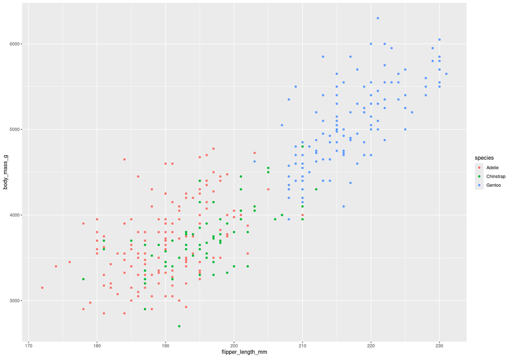

In mapping a categorical variable to the colour aesthetic, `ggplot2` automatically assigns a unique colour to each factor level (i.e. each species), a process known as **scaling**. `ggplot2` will also add a legend that explains which values correspond to which levels.

## Fourth step – Adding aesthetics and layers

Now, let’s add one more layer, a smooth curve displaying the relationship between body mass and flipper length. Since this is a new geometric object representing our data, we will add a new **geom**, namely `geom_smooth` based on a linear model (`lm`):

```r
ggplot(data = penguins,
       mapping = aes(x = flipper_length_mm,
                     y = body_mass_g,
                     color = species)) +
  geom_point() +
  geom_smooth(method = "lm")
```

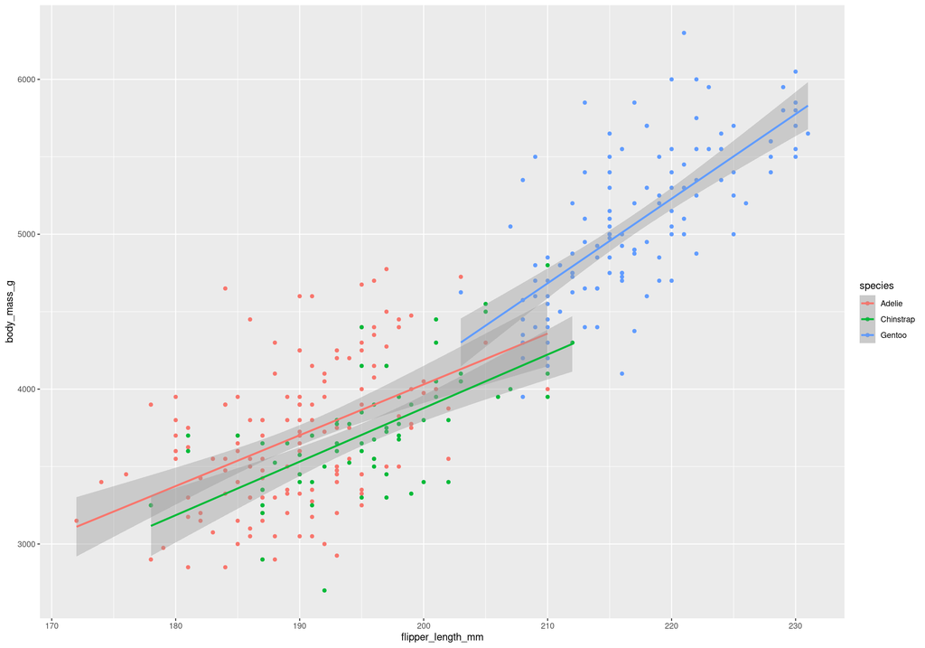

We have successfully added lines, but this plot does not look like our ultimate goal. Instead of having only one line for the entire data set, we have separate lines for each of the three penguin species. What went wrong?

## Fourth step – Adding aesthetics and layers

When aesthetics are defined in `ggplot()`, at the top level, they’re passed down to each of the subsequent **geom** layers of the plot. However, each geom function can also take a mapping argument, which allows for aesthetics at the local level. Here, we want point colours, but not lines separated by species, so we should specify `color = species` **locally** for `geom_point` only:

```r
ggplot(data = penguins,
       mapping = aes(x = flipper_length_mm,
                     y = body_mass_g)) +
  geom_point(mapping = aes(color = species)) +
  geom_smooth(method = "lm")
```

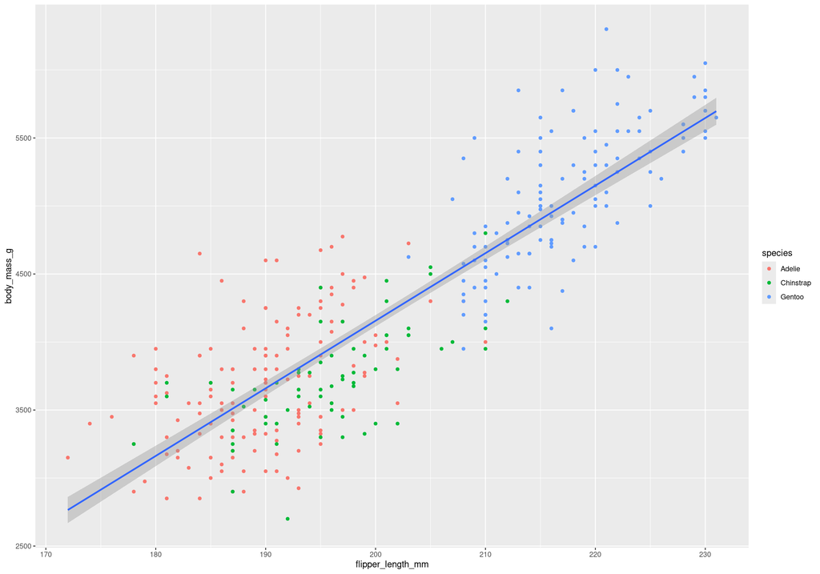

We are getting close to our ultimate goal… Some minor details are still missing though.

## Fourth step – Adding aesthetics and layers

Due to differences in colour perception (e.g. colour blindness), it is generally not a good idea to represent information using only colours on a plot. Therefore, in addition to colour, we can also map `species` to the `shape` aesthetic:

```r
ggplot(data = penguins,
       mapping = aes(x = flipper_length_mm,
                     y = body_mass_g)) +
  geom_point(mapping = aes(color = species,
                           shape = species)) +
  geom_smooth(method = "lm")
```

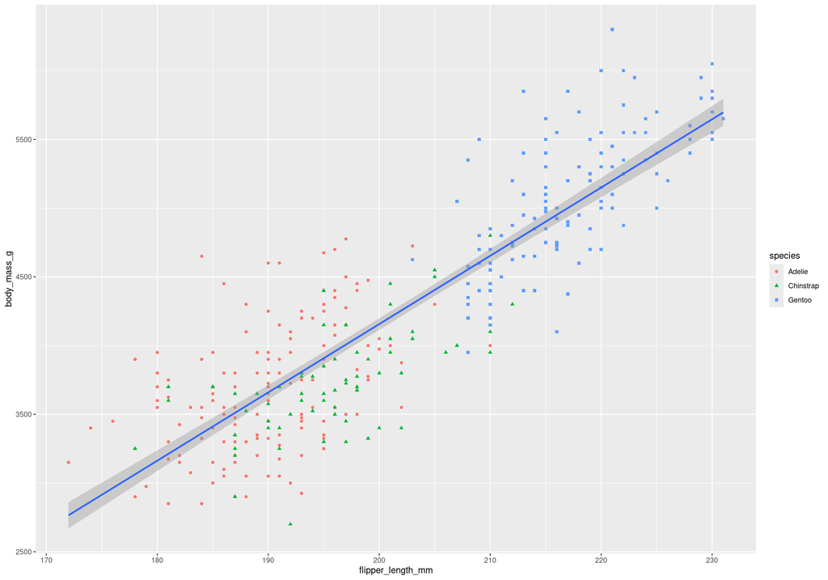

Note that the legend is automatically updated to reflect the different shapes of the points as well.

## Fifth step – Adjust scales, labels, titles, …

The “clean-up” work involves setting appropriate labels for title, subtitle, axes, and legend using the `labs` function and using the colourblind safe colour palette **scale_color_colorblind** from the `ggthemes` package (an extension of `ggplot2`):

```r
library(ggthemes)

ggplot(data = penguins,
       mapping = aes(x = flipper_length_mm,
                     y = body_mass_g)) +
  geom_point(mapping = aes(color = species,
                           shape = species)) +
  geom_smooth(method = "lm") +
  labs(x = "Flipper length (mm)",
       y = "Body mass (g)",
       title = "Body mass and flipper length",
       subtitle = "Dimensions for Adelie, Chinstrap, and Gentoo Penguins",
       color = "Species",
       shape = "Species") +
  scale_color_colorblind()
```

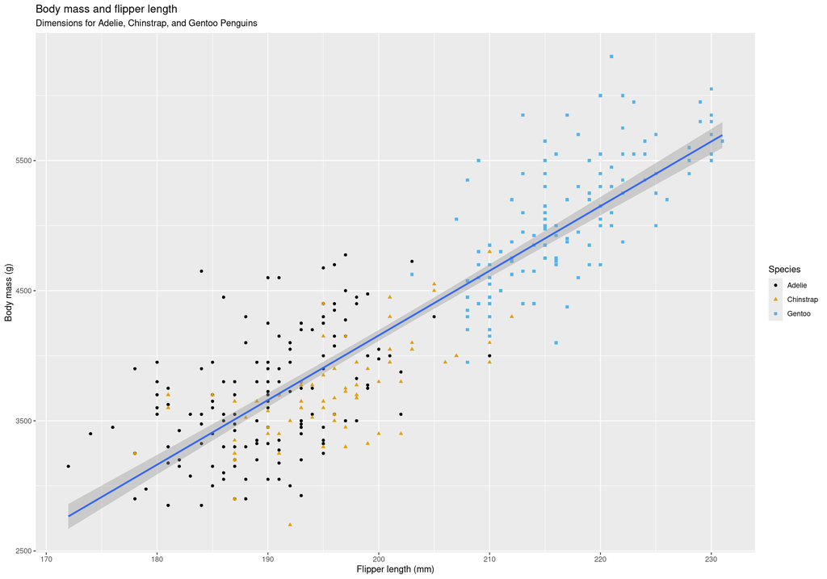

Now, we are done, we have built the plot of our ultimate goal step-by-step from the ground up. The example highlights the core principles of how `ggplot2` allows us to build nice-looking informative graphs with relatively little coding effort.

# Basic types of plots with `ggplot2`

## Steps in creating a plot with `ggplot2`

Conceptually, the steps we went through are the same for every plot created with `ggplot2`. Based on a **tidy** data set, we always proceed as follows:

- Telling `ggplot` about our data set.
- Specifying **aesthetic mappings**, i.e. what relationships we want to see and by what we want them represented.
- Additively layer on **geoms** as needed.
- Add and adapt aesthetics and layers until all relationships are displayed.
- Adjust scales, labels, titles, …

These steps are always the same. We will now only learn in greater detail about how to tell `ggplot` what to do by going through several examples of different data sets, aesthetic mappings, geoms and more. As with anything, the key to improvement is **LOTS** of trial and error…

## Visualizing a numerical variable – Histogram

Let’s say we want to visualize the distribution of body mass (in grams) across all penguins in the sample using a **histogram**. For this, we map the variable `body_mass_g` to `x` and use `geom_histogram`:

- Code
- Plot

```r
ggplot(penguins, aes(x = body_mass_g)) +
  geom_histogram()
```

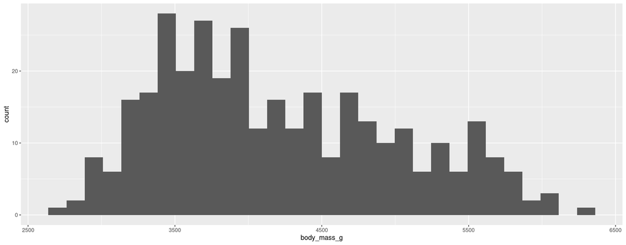

## Visualizing a numerical variable – Histogram

A histogram divides the x-axis into equally spaced bins and then uses the height of a bar to display the number of observations that fall in each bin. `ggplot2` by default creates 30 such bins. We can control this by setting `bins` ourselves:

- Code
- Plot

```r
ggplot(penguins, aes(x = body_mass_g)) +
  geom_histogram(bins = 15)
```

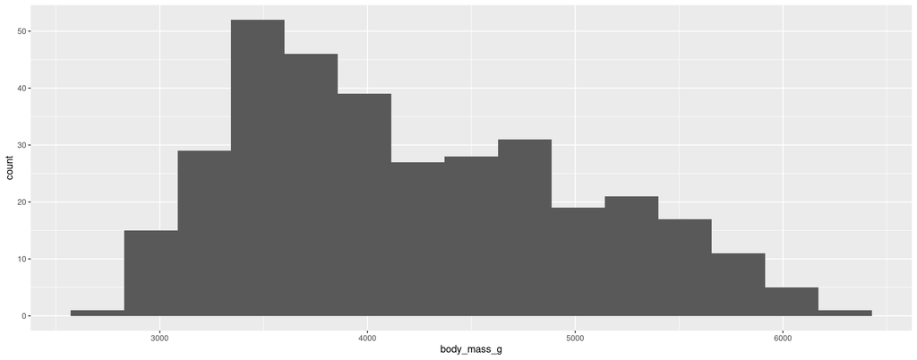

## Visualizing a numerical variable – Histogram

We do not like the colour of this histogram. Previously, we set the `color` aesthetic, but here we do not want to **map** colour to a variable. Instead we want to **set** it to a specific colour. This we do in the **geom**, not in the `aes`:

- Code
- Plot

```r
ggplot(penguins, aes(x = body_mass_g)) +
  geom_histogram(color = "deepskyblue4", bins = 15)
```

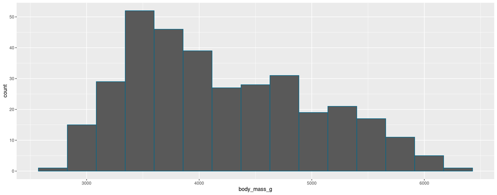

## Visualizing a numerical variable – Histogram

Hm, this is not what we wanted… `ggplot` only coloured the border line of the bars. Turns out that if we want to **fill** the bars in a specific colour, we need to use the `fill` argument of the `geom_histogram` function:

- Code
- Plot

```r
ggplot(penguins, aes(x = body_mass_g)) +
  geom_histogram(fill = "deepskyblue4", bins = 15)
```

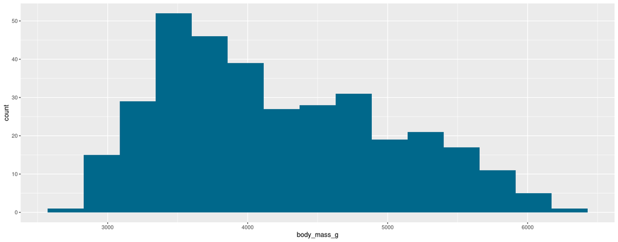

## Visualizing a numerical variable – Density plot

An alternative visualization for distributions of numerical variables is a **density plot**, which is a smoothed-out version of a histogram. To create one, we simply switch out our **geom** to `geom_density`:

- Code
- Plot

```r
ggplot(penguins, aes(x = body_mass_g)) +
  geom_density()
```

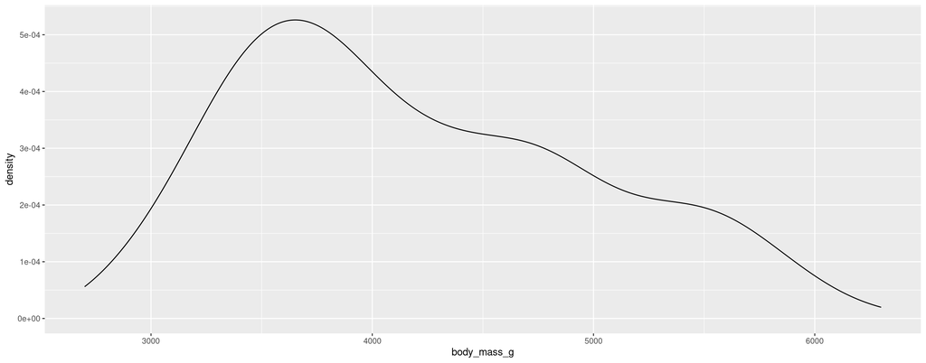

## Visualizing a numerical variable – Density plot

That’s a bit boring, let’s change the colour again (both of the line itself using `color` and the area below the curve using `fill`):

- Code
- Plot

```r
ggplot(penguins, aes(x = body_mass_g)) +
  geom_density(color = "deepskyblue4", fill = "deepskyblue4")
```

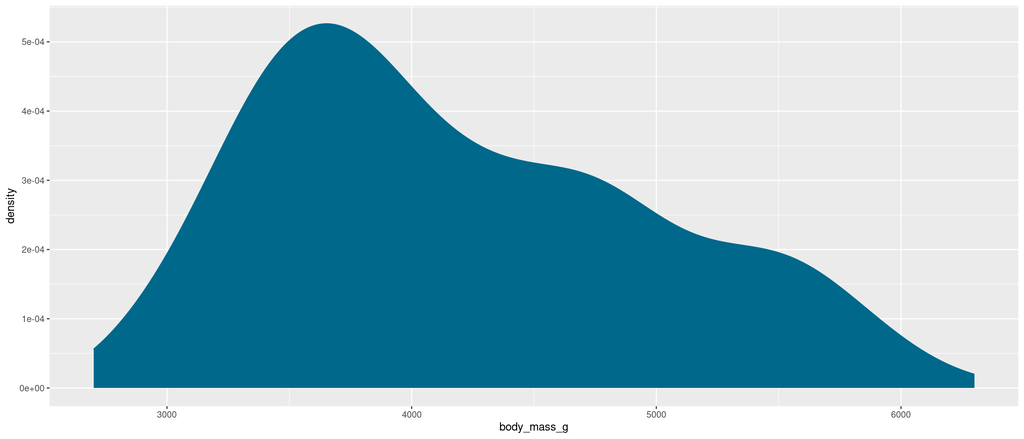

## Visualizing a categorical variable – Barplot

A simple **bar chart** visualizes the (absolute or relative) frequencies of the levels of a categorical variable. While we could use `ggplot` directly on the data, it is generally preferable to compute frequencies explicitly ourselves, e.g. for species:

- Code
- Plot

```r
species_freq <- as.data.frame(table(penguins$species))
names(species_freq)[1] <- "species"

# As we have already computed frequencies, we have to tell the bar geom
# that it should use the values as they are, i.e. use the "identity":
ggplot(species_freq, aes(x = species, y = Freq)) +
  geom_bar(stat = "identity", fill = "deepskyblue4")
```

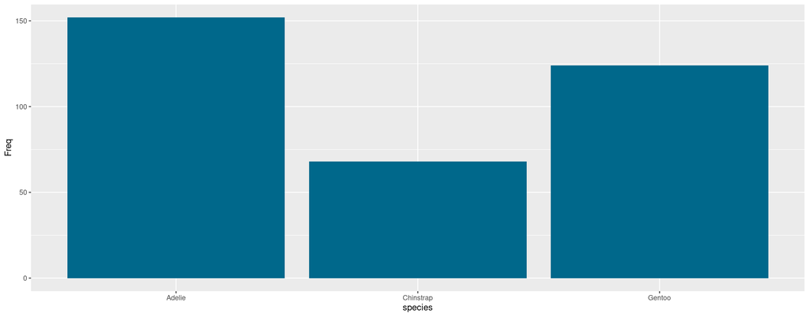

## Visualizing a categorical variable – Barplot

If the variable has a nominal (and not ordinal) scale, then it is usually preferable to order the bars based on their frequency. For this, we have to **reorder** the factor levels for the species:

- Code
- Plot

```r
ggplot(species_freq, aes(x = reorder(species, Freq, decreasing = TRUE), y = Freq)) +
  geom_bar(stat = "identity", fill = "deepskyblue4")
```

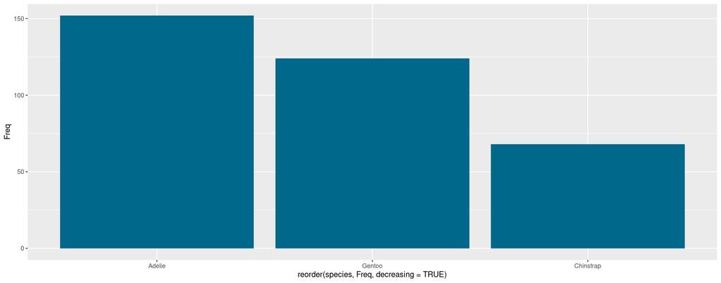

## Visualizing a categorical variable – Barplot

Often, we want the bars to be horizontal rather than vertical. To achieve this, we simply flip the axes using `coord_flip`. Additionally, we add nice axis labels:

- Code
- Plot

```r
ggplot(species_freq, aes(x = reorder(species, Freq, decreasing = TRUE), y = Freq)) +
  geom_bar(stat = "identity", fill = "deepskyblue4") +
  labs(x = "Penguin Species", y = "Observed frequency") +
  coord_flip()
```

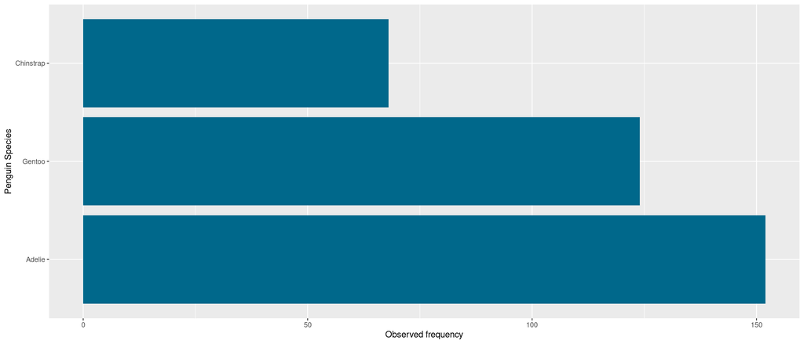

## A categorical and a numerical variable

To visualize the relationship between a categorical and a numerical variable, we can create **parallel boxplots**. For example, for the distribution of body weight by species, we could try:

- Code
- Plot

```r
ggplot(penguins, aes(x = species, y = body_mass_g, fill = species)) +
  geom_boxplot()
```

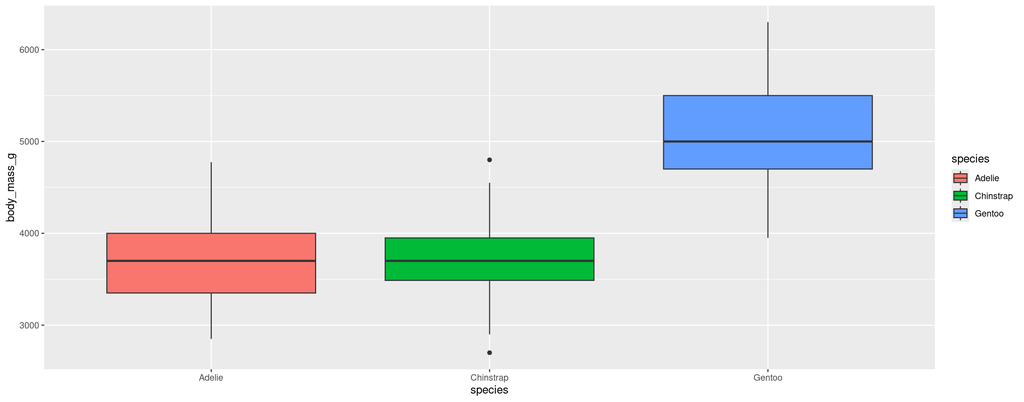

## A categorical and a numerical variable

An alternative to boxplots are so-called **violin plots**. In their simplest form, these are rotated density plots of the numerical variable in each category mirrored to create a symmetric, “violin-like” object:

- Code
- Plot

```r
ggplot(penguins, aes(x = species, y = body_mass_g, fill = species)) +
  geom_violin()
```

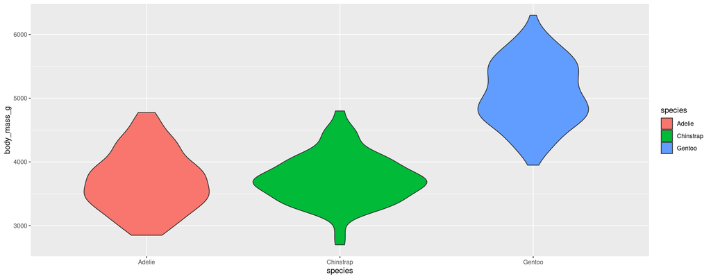

## A categorical and a numerical variable

Since density plots can also mask certain aspects of the distribution of the data, it is often advisable to additionally plot the actual data points on top of the violin plots. We can do this by layering a **point geom** on top:

- Code
- Plot

```r
ggplot(penguins, aes(x = species, y = body_mass_g, color = species)) +
  geom_violin() +
  geom_point()
```

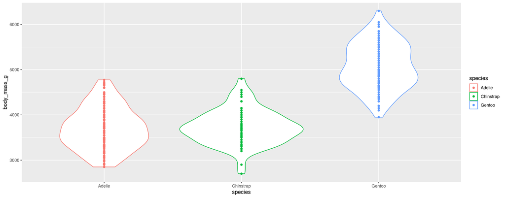

## A categorical and a numerical variable

If we have a lot of points close together, then they overlap and it becomes impossible to tell their distribution. To avoid this, we can slightly perturb the points in the `x` direction. This is achieved by switching to `geom_jitter`.

- Code
- Plot

```r
ggplot(penguins, aes(x = species, y = body_mass_g, color = species)) +
  geom_violin() +
  geom_jitter()
```

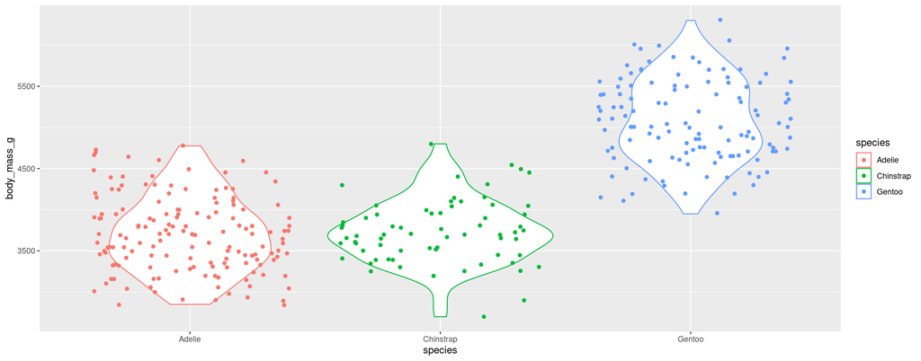

## A categorical and a numerical variable

Another alternative to displaying the distribution of body weights in the three penguin species is to combine their densities into one plot in the usual way, i.e. with the numerical variable on the `x` axis.

- Code
- Plot

```r
ggplot(penguins, aes(x = body_mass_g, fill = species)) +
  geom_density()
```

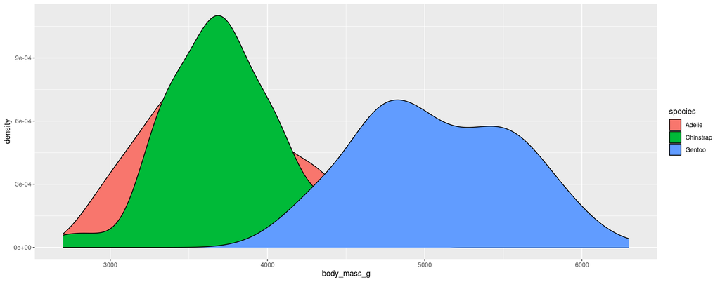

## A categorical and a numerical variable

Now, the densities are overlapping. To avoid this, we could of course not map the `fill` aesthetic. A nice alternative is to set the `alpha` aesthetic, which controls **transparency**. 0 is max transparency, 1 is max opaqueness (default).

- Code
- Plot

```r
ggplot(penguins, aes(x = body_mass_g, fill = species)) +
  geom_density(alpha = 0.5)
```

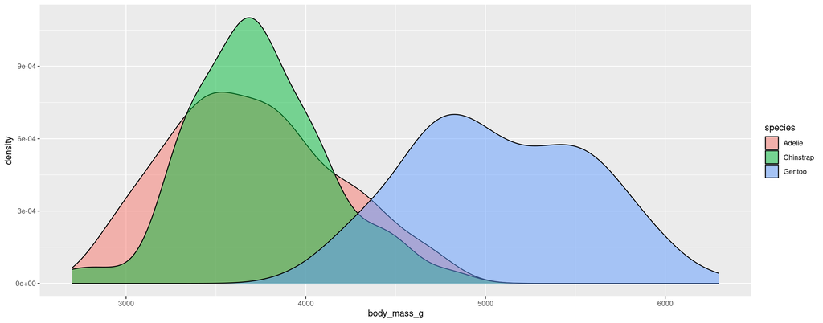

## Two categorical variables

We can use **grouped or stacked bar plots** to visualize the relationship between two categorical variables. For example, we might want to see how often the different species occur on the different islands.

- Code
- Plot

```r
species_freq <- as.data.frame(table(penguins$species, penguins$island))
names(species_freq)[1:2] <- c("species", "island")

ggplot(species_freq, aes(x = island, y = Freq, fill = species)) +
  geom_bar(stat = "identity")
```

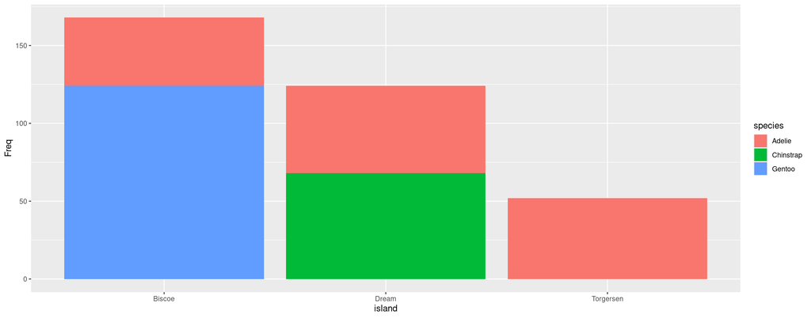